# Import required libraries & packages

# Linear Regression

### The original data

```python
## Regression - #Linear, Lasso, Ridge
#regression
from sklearn.linear_model import LinearRegression,Ridge,Lasso,RidgeCV
#evaluation metrics
from sklearn.metrics import mean_squared_log_error,mean_squared_error, r2_score,mean_absolute_error # for regression
```

SCALING

# scale

from sklearn.preprocessing import StandardScaler scaler = StandardScaler() num_col = ['temp', 'atemp', 'humidity', 'windspeed'] scaler.fit(X_train[num_col]) X_train[num_col] = scaler.transform(X_train[num_col]) X_test[num_col] = scaler.transform(X_test[num_col])

# x_train.head(), x_test.head()

Linear Regression with original data

```python
X_train,X_test,y_train,y_test=train_test_split(train_o_m.drop('count',axis=1),train_o_m['count'],test_size=0.1,random_state=81)

lr =LinearRegression()
lr.fit(X_train, y_train)
pred_lr  = lr.predict(X_test)
print(lr.score(X_train,y_train))
print(lr.score(X_test,y_test))
```

```
0.39103762234545736
0.3725616536406181
```

```python
print("Linear Regression")
print("R2_score",(r2_score(pred_lr,y_test)))
print("Mean Absolute Error",(mean_absolute_error(pred_lr,y_test)))
print("Mean Square Error",(mean_squared_error(pred_lr,y_test)))
print("Test Root Mean Square Error",(np.sqrt(mean_squared_error(pred_lr,y_test))))
```

```
Linear Regression
R2_score -0.6487026584664681
Mean Absolute Error 110.07411037347569
Mean Square Error 21308.824072296557
Test Root Mean Square Error 145.97542283650546
```

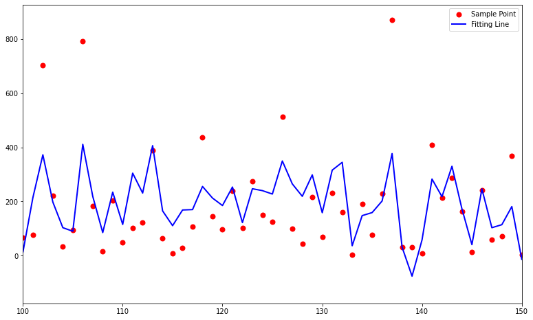

```python
xx=range(0,len(y_test))
plt.figure(figsize=(13,8))
plt.scatter(xx,y_test,color="red",label="Sample Point",linewidth=2)
plt.plot(xx,pred_lr,color="blue",label="Fitting Line",linewidth=2)
plt.xlim(100, 150)
plt.legend()
plt.show()
```

Linear Regression after spliting the features

```python
X_train,X_test,y_train,y_test=train_test_split(trainm_wo_outlier.drop('count',axis=1),trainm_wo_outlier['count'],test_size=0.1,random_state=81)
y_train = pd.DataFrame(y_train)
y_test = pd.DataFrame(y_test)

lr2 = LinearRegression()
lr2.fit(X_train, y_train)
pred_lr2  = lr2.predict(X_test)
print(lr2.score(X_train,y_train))
print(lr2.score(X_test,y_test))
```

```
0.45968318117291396
0.4545039526214556
```

```python
print("Linear Regression with other table")
print("R2_score",(r2_score(pred_lr2,y_test)))
print("Mean Absolute Error",(mean_absolute_error(pred_lr2,y_test)))
print("Mean Square Error",(mean_squared_error(pred_lr2,y_test)))
print("Root Mean Square Error",(np.sqrt(mean_squared_error(pred_lr2,y_test))))
```

```
Linear Regression with other table
R2_score -0.1985739562239146
Mean Absolute Error 0.8561677023863911
Mean Square Error 1.2069775231158617
Root Mean Square Error 1.0986252878556282
```

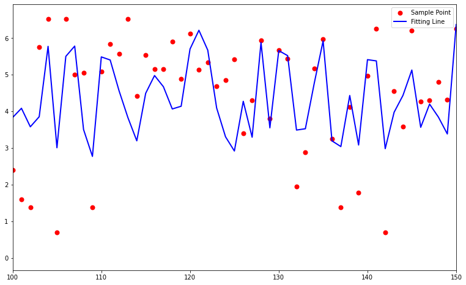

```python
xx=range(0,len(y_test))
plt.figure(figsize=(13,8))
plt.scatter(xx,y_test,color="red",label="Sample Point",linewidth=2)
plt.plot(xx,pred_lr2,color="blue",label="Fitting Line",linewidth=2)
plt.xlim(100, 150)
plt.legend()
plt.show()
```

## Lasso

```python
#Lasso
X_train,X_test,y_train,y_test=train_test_split(train_o_m.drop('count',axis=1),train_o_m['count'],
                                               test_size=0.1,random_state=81)
param_test = {'max_iter':[5000],'alpha':[1e-10, 1e-8, 1e-4,1e-2, 1, 5, 10, 100, 500, 1000]}
#gsearch = GridSearchCV(Lasso(fit_intercept=True, normalize=True, selection='random'),refit=True,
gsearch = GridSearchCV(Lasso(fit_intercept=True, normalize=True, selection='random'),refit=True, param_grid = param_test, scoring='r2', cv=5)
gsearch.fit(X_train,y_train)
pred_las = gsearch.predict(X_test)
gsearch.best_params_
```

```
{'alpha': 1e-08, 'max_iter': 5000}
```

```python
print(gsearch.scoring, ": Best params - ",gsearch.best_params_)
print("Lasso")
print("R2_score :",(r2_score(pred_las,y_test))) #99.99% variance is explained by the model
print("Mean Absolute Error :",(mean_absolute_error(pred_las,y_test)))
print("Mean Square Error :",(mean_squared_error(pred_las,y_test)))
print("Root Mean Square Error :",(np.sqrt(mean_squared_error(pred_las,y_test))))
```

```
r2 : Best params -  {'alpha': 1e-08, 'max_iter': 5000}
Lasso
R2_score : -0.6487026774106868
Mean Absolute Error : 110.07410934056408
Mean Square Error : 21308.823854883274
Root Mean Square Error : 145.97542209181404
```

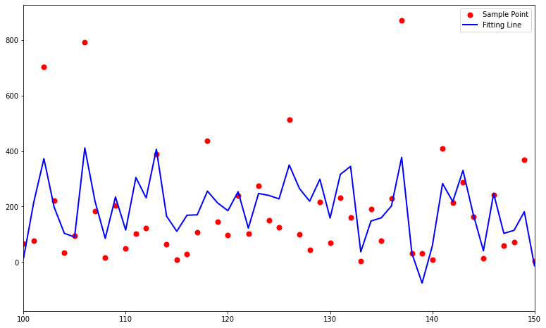

```python
xx=range(0,len(y_test))
plt.figure(figsize=(13,8))
plt.scatter(xx,y_test,color="red",label="Sample Point",linewidth=2)
plt.plot(xx,pred_las,color="blue",label="Fitting Line",linewidth=2)
plt.xlim(100, 150)
plt.legend()
plt.show()
```

Lasso after spitting the feature -

```python
X_train,X_test,y_train,y_test=train_test_split(trainm_wo_outlier.drop('count',axis=1),trainm_wo_outlier['count'],test_size=0.1,random_state=81)
y_train = pd.DataFrame(y_train)
y_test = pd.DataFrame(y_test)
```

```python
param_test = {'max_iter':[5000],'alpha':[1e-10, 1e-8, 1e-4,1e-2, 1, 5, 10, 100, 500, 1000]}
gsearch2 = GridSearchCV(Lasso(fit_intercept=True, normalize=True, selection='random'),refit=True, param_grid = param_test, scoring='r2', cv=5)
gsearch2.fit(X_train,y_train)
pred_las2 = gsearch2.predict(X_test)
gsearch.best_params_
```

```
{'alpha': 1e-08, 'max_iter': 5000}
```

```python
print(gsearch.scoring, ": Best params - ",gsearch.best_params_)
print("Lasso")
print("R2_score",(r2_score(pred_las2,y_test)))
print("Mean Absolute Error",(mean_absolute_error(pred_las2,y_test)))
print("Mean Square Error",(mean_squared_error(pred_las2,y_test)))
print("Root Mean Square Error",(np.sqrt(mean_squared_error(pred_las2,y_test))))
```

```
r2 : Best params -  {'alpha': 1e-08, 'max_iter': 5000}
Lasso
R2_score -0.19857744865395044
Mean Absolute Error 0.856167807999159
Mean Square Error 1.2069768549464492
Root Mean Square Error 1.0986249837621795
```

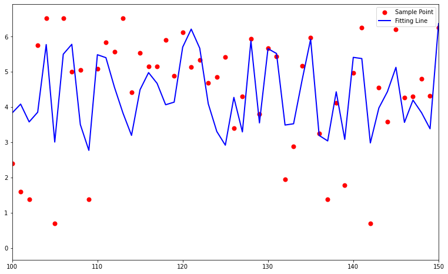

```python
xx=range(0,len(y_test))
plt.figure(figsize=(13,8))
plt.scatter(xx,y_test,color="red",label="Sample Point",linewidth=2)
plt.plot(xx,pred_las2,color="blue",label="Fitting Line",linewidth=2)
plt.xlim(100, 150)
plt.legend()
plt.show()
```

## Ridge

Ridge on original data

```python
X_train,X_test,y_train,y_test=train_test_split(train_o_m.drop('count',axis=1),train_o_m['count'],
                                               test_size=0.1,random_state=81)

# Ridge
param_test = {'max_iter':[5000],'alpha':[1e-10, 1e-8, 1e-4,1e-2, 1, 5, 10, 100, 500, 1000]}
rig = GridSearchCV(Ridge(),refit=True,
                       param_grid = param_test, scoring='r2', cv=5)
rig.fit(X_train,y_train)
pred_rig= rig.predict(X_test)
rig.best_params_
```

```
{'alpha': 10, 'max_iter': 5000}
```

```python
print(gsearch.scoring, ": Best params - ",gsearch.best_params_)
print("Ridge")
print("R2_score",(r2_score(pred_rig,y_test))) #99.99% variance is explained by the model
print("Mean Absolute Error",(mean_absolute_error(pred_rig,y_test)))
print("Mean Square Error",(mean_squared_error(pred_rig,y_test)))
print("Root Mean Square Error",(np.sqrt(mean_squared_error(pred_rig,y_test))))
```

```
r2 : Best params -  {'alpha': 1e-08, 'max_iter': 5000}
Ridge
R2_score -0.6504185184160904
Mean Absolute Error 110.05374655783875
Mean Square Error 21307.366509923402
Root Mean Square Error 145.9704302587459
```

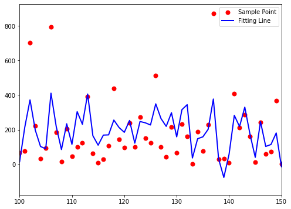

```python
xx=range(0,len(y_test))
plt.figure(figsize=(8,6))
plt.scatter(xx,y_test,color="red",label="Sample Point",linewidth=2)
plt.plot(xx,pred_rig,color="blue",label="Fitting Line",linewidth=2)
plt.xlim(100, 150)
plt.legend()
plt.show()
```

Ridge on new data

```python
X_train,X_test,y_train,y_test=train_test_split(trainm_wo_outlier.drop('count',axis=1),trainm_wo_outlier['count'],test_size=0.1,random_state=81)
y_train = pd.DataFrame(y_train)
y_test = pd.DataFrame(y_test)
```

```python
# Ridge
param_test = {'max_iter':[5000],'alpha':[1e-10, 1e-8, 1e-4,1e-2, 1, 5, 10, 100, 500, 1000]}
rig = GridSearchCV(Ridge(),refit=True,
                       param_grid = param_test, scoring='r2', cv=5)
rig.fit(X_train,y_train)
pred_rig2= rig.predict(X_test)
rig.best_params_
```

```
{'alpha': 10, 'max_iter': 5000}
```

```python
print(gsearch.scoring, ": Best params - ",gsearch.best_params_)
print("Lasso")
print("R2_score",(r2_score(pred_rig2,y_test))) #99.99% variance is explained by the model
print("Mean Absolute Error",(mean_absolute_error(pred_rig2,y_test)))
print("Mean Square Error",(mean_squared_error(pred_rig2,y_test)))
print("Root Mean Square Error",(np.sqrt(mean_squared_error(pred_rig2,y_test))))
```

```
r2 : Best params -  {'alpha': 1e-08, 'max_iter': 5000}
Lasso
R2_score -0.19869383506406435
Mean Absolute Error 0.8561886760639699
Mean Square Error 1.2067789304543484
Root Mean Square Error 1.098534901791631
```

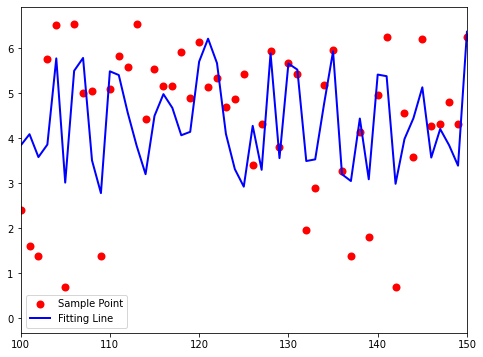

```python
xx=range(0,len(y_test))
plt.figure(figsize=(8,6))
plt.scatter(xx,y_test,color="red",label="Sample Point",linewidth=2)
plt.plot(xx,pred_rig2,color="blue",label="Fitting Line",linewidth=2)
plt.xlim(100, 150)
plt.legend()
plt.show()
```

# Knn

```python
from sklearn.neighbors import KNeighborsRegressor
X_train,X_test,y_train,y_test=train_test_split(train_o_m.drop('count',axis=1),train_o_m['count'],
                                               test_size=0.1,random_state=81)

# knn
error_rate = []
n_neighbors=[]
for i in range (0,50,5):
    if(i!=0):
        n_neighbors.append(i)
params_dict={'n_neighbors':n_neighbors,'n_jobs':[-1]}
c_knn=GridSearchCV(estimator=KNeighborsRegressor(), param_grid=params_dict, scoring='r2')
c_knn
c_knn.fit(X_train,y_train)
pred_knn  = c_knn.predict(X_test)
c_knn.best_params_
```

```
{'n_jobs': -1, 'n_neighbors': 5}
```

```python
print(c_knn.scoring, ": Best params - ",c_knn.best_params_)
print("Knn")
print("R2_score",(r2_score(pred_knn,y_test))) #99.94% variance is explained by the model
print("Mean Absolute Error",(mean_absolute_error(pred_knn,y_test)))
print("Mean Square Error",(mean_squared_error(pred_knn,y_test)))
print("Root Mean Square Error",(np.sqrt(mean_squared_error(pred_knn,y_test))))
```

```
r2 : Best params -  {'n_jobs': -1, 'n_neighbors': 5}
Knn
R2_score 0.29912999892682257
Mean Absolute Error 81.16418732782368
Mean Square Error 14599.104536271809
Root Mean Square Error 120.82675422385478
```

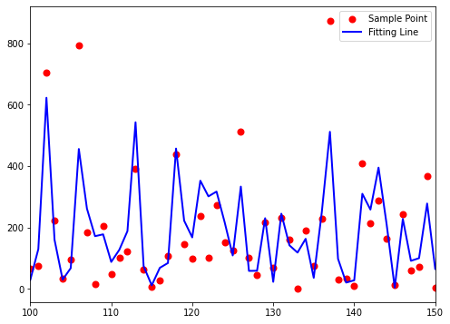

```python
xx=range(0,len(y_test))
plt.figure(figsize=(8,6))
plt.scatter(xx,y_test,color="red",label="Sample Point",linewidth=2)
plt.plot(xx,pred_knn,color="blue",label="Fitting Line",linewidth=2)
plt.xlim(100, 150)
plt.legend()
plt.show()
```

New data

```python
X_train,X_test,y_train,y_test=train_test_split(trainm_wo_outlier.drop('count',axis=1),trainm_wo_outlier['count'],test_size=0.1,random_state=81)
y_train = pd.DataFrame(y_train)
y_test = pd.DataFrame(y_test)
```

```python
print(X_test.shape)
print(X_train.shape)
print(y_test.shape)
print(y_train.shape)
```

```
(1043, 14)
(9384, 14)
(1043, 1)
(9384, 1)
```

```python
n_neighbors=[]
for i in range (0,50,5):
    if(i!=0):
        n_neighbors.append(i)
params_dict={'n_neighbors':n_neighbors,'n_jobs':[-1]}
c_knn2=GridSearchCV(estimator=KNeighborsRegressor(), param_grid=params_dict, scoring='r2')
#c_knn2
c_knn2.fit(X_train,y_train)
pred_knn2  = c_knn2.predict(X_test)
```

```python
print(c_knn2.scoring, ": Best params - ",c_knn2.best_params_)
print("Knn")
print("R2_score",(r2_score(pred_knn2,y_test))) #99.94% variance is explained by the model
print("Mean Absolute Error",(mean_absolute_error(pred_knn2,y_test)))
print("Mean Square Error",(mean_squared_error(pred_knn2,y_test)))
print("Root Mean Square Error",(np.sqrt(mean_squared_error(pred_knn2,y_test))))
```

```
r2 : Best params -  {'n_jobs': -1, 'n_neighbors': 5}
Knn
R2_score 0.5971887832979876
Mean Absolute Error 0.5856742787473966
Mean Square Error 0.6730042677026506
Root Mean Square Error 0.820368373173083
```

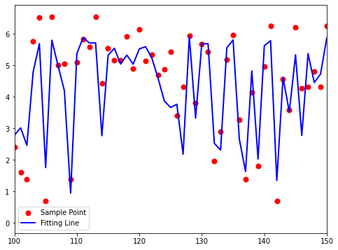

```python
xx=range(0,len(y_test))
plt.figure(figsize=(8,6))
plt.scatter(xx,y_test,color="red",label="Sample Point",linewidth=2)
plt.plot(xx,pred_knn2,color="blue",label="Fitting Line",linewidth=2)
plt.xlim(100, 150)
plt.legend()
plt.show()
```

```python
test_o = pd.read_csv("./test.csv")
train = test_o.copy()
train["hour"] = [t.hour for t in pd.DatetimeIndex(train.datetime)]
train["day"] = [t.dayofweek for t in pd.DatetimeIndex(train.datetime)]
train["month"] = [t.month for t in pd.DatetimeIndex(train.datetime)]
train['year'] = [t.year for t in pd.DatetimeIndex(train.datetime)]
train['year'] = train['year'].map({2011:0, 2012:1})
season=pd.get_dummies(train['season'],prefix='season')
train=pd.concat([train,season],axis=1)
name_change = {'season_1' : 'spring',
               'season_2' : 'summer',
               'season_3' : 'fall',
               'season_4' : 'winter'}
train = train.rename(columns = name_change)
train.drop(['season'],inplace=True,axis=1)
train.drop('datetime',axis=1,inplace=True)
train.drop(["year"],axis=1,inplace = True)
test = train
```

```python
test.shape
```

```
(6493, 14)
```

```python
test.dtypes
```

```
holiday         int64
workingday      int64
weather         int64
temp          float64
atemp         float64
humidity        int64
windspeed     float64
hour            int64
day             int64
month           int64
spring          uint8
summer          uint8
fall            uint8
winter          uint8
dtype: object
```

```python
pred_rf2=clf_rf2.predict(test)
a={'datetime':test_o['datetime'],'count':pred_rf2}
ans=pd.DataFrame(a)
ans.head()
```

|  | datetime | count |
| --- | --- | --- |
| 0 | 2011-01-20 00:00:00 | 2.623210 |
| 1 | 2011-01-20 01:00:00 | 1.707088 |
| 2 | 2011-01-20 02:00:00 | 1.236057 |
| 3 | 2011-01-20 03:00:00 | 1.123661 |
| 4 | 2011-01-20 04:00:00 | 0.910597 |